# Tugas Unsupervised Learning

Dinda Dwi Anugrah Pertiwi

# Data

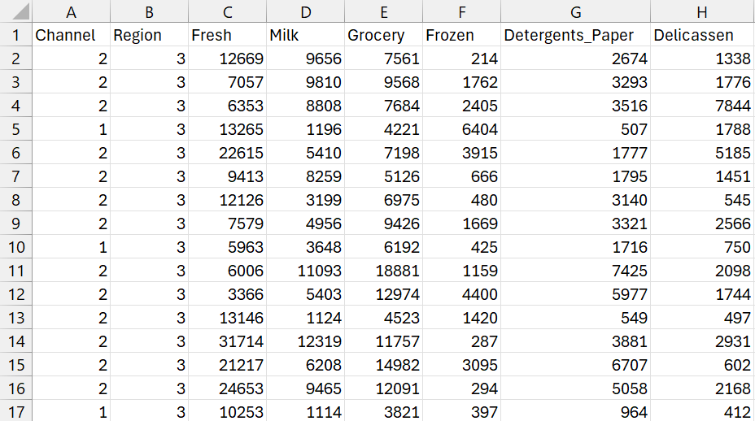

[Sumber data](https://archive.ics.uci.edu/dataset/292/wholesale+customers)

Data yang digunakan dalam penelitian ini adalah **Wholesale Customers Dataset** yang diperoleh dari **Machine Learning Repository**. Dataset ini berisi informasi terkait pola pembelian pelanggan dari sebuah distributor grosir, yang mencakup berbagai kategori produk.

Dataset terdiri dari **440 observasi** (pelanggan) dan **8 variabel**, yang meliputi **dua variabel kategorik** yaitu Channel dan Region, serta **enam variabel numerik** yang merepresentasikan jumlah pengeluaran tahunan pelanggan pada masing-masing kategori produk, yaitu: Fresh, Milk, Grocery, Frozen, Detergents_Paper, dan Delicassen.

Variabel Channel menunjukkan jenis pelanggan (misalnya Horeca atau Retail), sedangkan Region menunjukkan wilayah geografis pelanggan. Sementara itu, keenam variabel numerik mencerminkan intensitas pembelian pada masing-masing kategori produk dalam satuan moneter.

```r
# Input Data
data_whole <- read.csv("C:/Users/dals/OneDrive - untirta.ac.id/KULIAH/Sem 6/Unsupervised/Data/Wholesale customers data.csv", sep = ",")
```

```r
# Eksplorasi Data
head(data_whole)
```

|  | Channel | Region | Fresh | Milk | Grocery | Frozen | Detergents_Paper | Delicassen |
| --- | --- | --- | --- | --- | --- | --- | --- | --- |
| 1 | 2 | 3 | 12669 | 9656 | 7561 | 214 | 2674 | 1338 |
| 2 | 2 | 3 | 7057 | 9810 | 9568 | 1762 | 3293 | 1776 |
| 3 | 2 | 3 | 6353 | 8808 | 7684 | 2405 | 3516 | 7844 |
| 4 | 1 | 3 | 13265 | 1196 | 4221 | 6404 | 507 | 1788 |
| 5 | 2 | 3 | 22615 | 5410 | 7198 | 3915 | 1777 | 5185 |
| 6 | 2 | 3 | 9413 | 8259 | 5126 | 666 | 1795 | 1451 |

```r
str(data_whole)
```

```
## 'data.frame':    440 obs. of  8 variables:
##  $ Channel         : int  2 2 2 1 2 2 2 2 1 2 ...
##  $ Region          : int  3 3 3 3 3 3 3 3 3 3 ...
##  $ Fresh           : int  12669 7057 6353 13265 22615 9413 12126 7579 5963 6006 ...
##  $ Milk            : int  9656 9810 8808 1196 5410 8259 3199 4956 3648 11093 ...
##  $ Grocery         : int  7561 9568 7684 4221 7198 5126 6975 9426 6192 18881 ...
##  $ Frozen          : int  214 1762 2405 6404 3915 666 480 1669 425 1159 ...
##  $ Detergents_Paper: int  2674 3293 3516 507 1777 1795 3140 3321 1716 7425 ...
##  $ Delicassen      : int  1338 1776 7844 1788 5185 1451 545 2566 750 2098 ...
```

```r
summary(data_whole)
```

```
##     Channel          Region          Fresh             Milk
##  Min.   :1.000   Min.   :1.000   Min.   :     3   Min.   :   55
##  1st Qu.:1.000   1st Qu.:2.000   1st Qu.:  3128   1st Qu.: 1533
##  Median :1.000   Median :3.000   Median :  8504   Median : 3627
##  Mean   :1.323   Mean   :2.543   Mean   : 12000   Mean   : 5796
##  3rd Qu.:2.000   3rd Qu.:3.000   3rd Qu.: 16934   3rd Qu.: 7190
##  Max.   :2.000   Max.   :3.000   Max.   :112151   Max.   :73498
##     Grocery          Frozen        Detergents_Paper    Delicassen
##  Min.   :    3   Min.   :   25.0   Min.   :    3.0   Min.   :    3.0
##  1st Qu.: 2153   1st Qu.:  742.2   1st Qu.:  256.8   1st Qu.:  408.2
##  Median : 4756   Median : 1526.0   Median :  816.5   Median :  965.5
##  Mean   : 7951   Mean   : 3071.9   Mean   : 2881.5   Mean   : 1524.9
##  3rd Qu.:10656   3rd Qu.: 3554.2   3rd Qu.: 3922.0   3rd Qu.: 1820.2
##  Max.   :92780   Max.   :60869.0   Max.   :40827.0   Max.   :47943.0
```

```r
colSums(is.na(data_whole))
```

```
##          Channel           Region            Fresh             Milk
##                0                0                0                0
##          Grocery           Frozen Detergents_Paper       Delicassen
##                0                0                0                0
```

Berdasarkan hasil eksplorasi data, dataset wholesale terdiri dari 440 observasi dengan mayoritas variabel berupa data numerik yang merepresentasikan jumlah pembelian, serta dua variabel kategorik yaitu Channel dan Region. Seluruh variabel tidak memiliki missing value sehingga data siap digunakan untuk analisis.

Secara deskriptif, terlihat bahwa hampir semua variabel memiliki rentang nilai yang sangat lebar dan nilai rata-rata yang lebih besar dari median, yang menunjukkan distribusi miring ke kanan (*right-skewed*) serta adanya outlier. Hal ini mengindikasikan adanya perbedaan signifikan antar pelanggan, di mana sebagian kecil pelanggan memiliki tingkat pembelian yang sangat tinggi.

# Model 1

## Jarak Numerik (Euclidean)

### Penyelesaian

```r
# Package Yang Digunakan
library(corrplot)
```

```r
# Memilih Variabel Numerik
data_numerik <- data_whole[, 3:8]
```

```r
# Eksplorasi Data
summary(data_numerik)
```

```
##      Fresh             Milk          Grocery          Frozen
##  Min.   :     3   Min.   :   55   Min.   :    3   Min.   :   25.0
##  1st Qu.:  3128   1st Qu.: 1533   1st Qu.: 2153   1st Qu.:  742.2
##  Median :  8504   Median : 3627   Median : 4756   Median : 1526.0
##  Mean   : 12000   Mean   : 5796   Mean   : 7951   Mean   : 3071.9
##  3rd Qu.: 16934   3rd Qu.: 7190   3rd Qu.:10656   3rd Qu.: 3554.2
##  Max.   :112151   Max.   :73498   Max.   :92780   Max.   :60869.0
##  Detergents_Paper    Delicassen
##  Min.   :    3.0   Min.   :    3.0
##  1st Qu.:  256.8   1st Qu.:  408.2
##  Median :  816.5   Median :  965.5
##  Mean   : 2881.5   Mean   : 1524.9
##  3rd Qu.: 3922.0   3rd Qu.: 1820.2
##  Max.   :40827.0   Max.   :47943.0
```

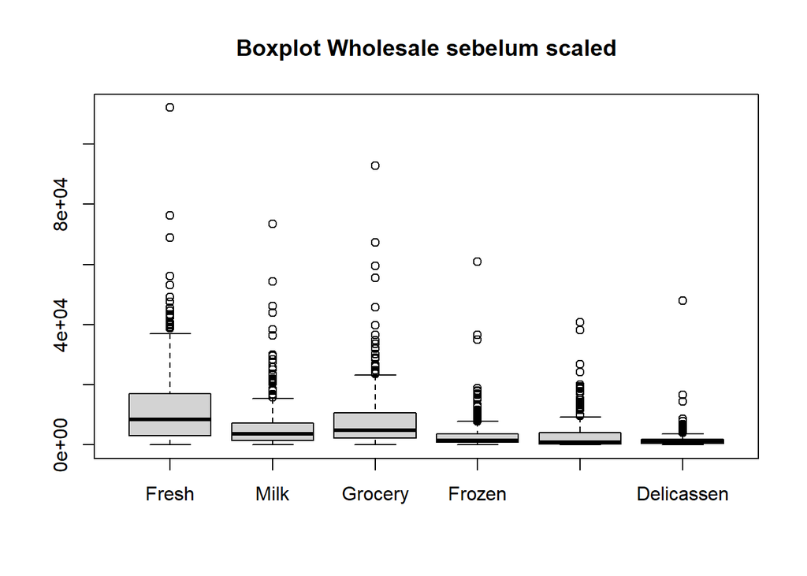

```r
boxplot(data_numerik, main = "Boxplot Wholesale sebelum scaled")
```

Berdasarkan boxplot sebelum dilakukan standarisasi, terlihat bahwa seluruh variabel memiliki rentang nilai yang sangat berbeda. Variabel Fresh dan Grocery memiliki skala yang jauh lebih besar dibandingkan dengan variabel lainnya, sedangkan variabel Frozen dan Delicassen memiliki rentang yang lebih kecil. Selain itu, terlihat banyak tiik yang berada di luar (*outlier*) pada hampir semua variabel, yang menunjukkan adanya nilai ekstrem dalam data. Kondisi ini mengidentifikasikan bahwa data bersifat tidak simetris (*skewed*) dan memiliki sebaran yang tidak merata.

Banyaknya outlier yang terdeteksi menunjukkan bahwa terdapat beberapa pelanggan dengan pola pembelian yang sangat berbeda dibandingkan mayoritas. Hal ini dapat menjadi indikasi adanya segmen pelanggan khusus.

```r
# Standarisasi Data
data_scaled <- scale(data_numerik)
```

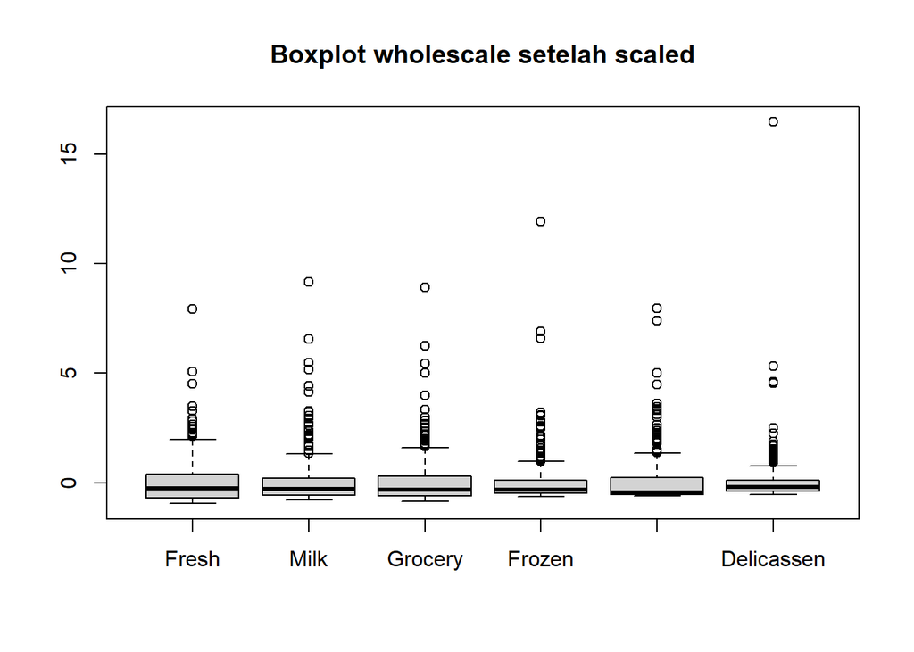

```r
# Eksplorasi Data Setelah Standarisasi
boxplot(data_scaled, main = "Boxplot wholescale setelah scaled")
```

Setelah dilakukan standarisasi menggunakan Z-score, terlihat bahwa seluruh variabel telah berada pada skala yang sama, yaitu dengan rata-rata mendekati nol dan penyebaran yang relatif seragam. Hal ini menunjukkan bahwa proses standarisasi berhasil menghilangkan perbedaan skala antar variabel. Namun, *outlier* masih tetap terlihat pada beberapa variabel yang menunjukkan bahwa standarisasi tidak menghilangkan nilai yang ekstrem, melainkan menyesuaikan skala data.

```r
# Melihat Outlier
Q1 <- apply(data_numerik, 2, quantile, 0.25)
Q3 <- apply(data_numerik, 2, quantile, 0.75)
IQR <- Q3 - Q1
lower <- Q1 - 1.5 * IQR
upper <- Q3 + 1.5 * IQR

outlier <- data_numerik < lower | data_numerik > upper
colSums(outlier)
```

[output not shown]

```r
# Melihat Multikolinear
cor(data_scaled)
```

```
##                        Fresh      Milk     Grocery      Frozen Detergents_Paper
## Fresh             1.00000000 0.1005098 -0.01185387  0.34588146       -0.1019529
## Milk              0.10050977 1.0000000  0.72833512  0.12399376        0.6618157
## Grocery          -0.01185387 0.7283351  1.00000000 -0.04019274        0.9246407
## Frozen            0.34588146 0.1239938 -0.04019274  1.00000000       -0.1315249
## Detergents_Paper -0.10195294 0.6618157  0.92464069 -0.13152491        1.0000000
## Delicassen        0.24468997 0.4063683  0.20549651  0.39094747        0.0692913
##                  Delicassen
## Fresh             0.2446900
## Milk              0.4063683
## Grocery           0.2054965
## Frozen            0.3909475
## Detergents_Paper  0.0692913
## Delicassen        1.0000000
```

```r
round(cor(data_scaled), 2)
```

```
##                  Fresh Milk Grocery Frozen Detergents_Paper Delicassen
## Fresh             1.00 0.10   -0.01   0.35            -0.10       0.24
## Milk              0.10 1.00    0.73   0.12             0.66       0.41
## Grocery          -0.01 0.73    1.00  -0.04             0.92       0.21
## Frozen            0.35 0.12   -0.04   1.00            -0.13       0.39
## Detergents_Paper -0.10 0.66    0.92  -0.13             1.00       0.07
## Delicassen        0.24 0.41    0.21   0.39             0.07       1.00
```

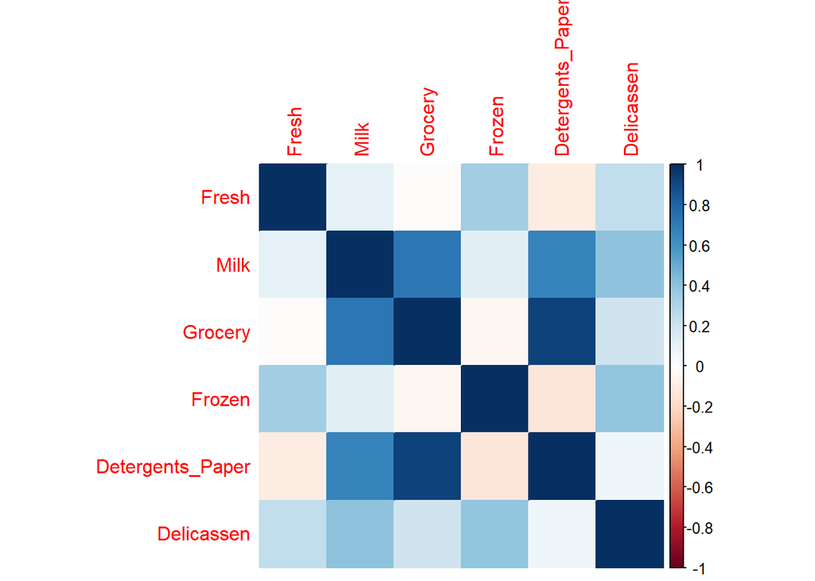

```r
corrplot(cor(data_scaled), method = "color")
```

Berdasarkan hasil analisis korelasi, terdapat beberapa pasangan variabel yang memiliki hubungan yang cukup kuat. Variabel Grocery dan Detergents_Paper menunjukkan korelasi yang sangat tinggi sebesar 0.92, yang mengindikasikan bahwa kedua variabel tersebut memiliki pola yang sangat mirip. Selain itu, variabel Milk juga memiliki korelasi yang cukup kuat dengan Grocery (0.73) dan Detergents_Paper (0.66). Hal ini menunjukkan bahwa pelanggan yang memiliki pengeluaran tinggi pada satu kategori cenderung memiliki pengeluaran tinggi pada kategori lainnya.

```r
# Jarak Euclidean
euclid <- dist(data_scaled, method = "euclidean")
summary(euclid)
```

```
##     Min.  1st Qu.   Median     Mean  3rd Qu.     Max.
##  0.04433  1.28361  1.97554  2.58190  3.02431 21.24426
```

Berdasarkan hasil perhitungan Euclidean Distance, nilai jarak antar observasi memiliki rentang yang cukup lebar, dengan nilai minimum sebesar 0.044 dan maksimum mencapai 21.244. Hal ini menunjukkan bahwa terdapat pasangan pelanggan yang sangat mirip, namun juga ada yang sangat berbeda. Nilai median sebesar 1.976 dan rata-rata sebesar 2.582 menunjukkan bahwa secara umum jarak antar pelanggan berada pada tingkat sedang, sehingga tidak semua data memiliki kemiripan yang tinggi. Selain itu, adanya nilai maksimum yang jauh lebih besar dibandingkan kuartil ketiga (3.024) mengindikasikan adanya beberapa observasi yang sangat berbeda dari yang lain.

```r
# Konversi Ke Dalam Bentuk Matrix
matrix_euclid <- as.matrix(euclid)
matrix_euclid[1:5,1:5]
```

```
##          1        2        3        4        5
## 1 0.000000 0.620152 2.412450 1.815908 1.851574
## 2 0.620152 0.000000 2.170333 1.781998 1.920911
## 3 2.412450 2.170333 0.000000 2.680215 1.728199
## 4 1.815908 1.781998 2.680215 0.000000 1.659964
## 5 1.851574 1.920911 1.728199 1.659964 0.000000
```

Berdasarkan hasil matrix jarak, terlihat bahwa nilai diagonal bernilai nol yang menunjukkan jarak suatu observasi dengan dirinya sendiri, serta matriks bersifat simetris. Beberapa nilai jarak yang kecil antar observasi menunjukkan adanya kemiripan karakteristik pelanggan, yang menjadi indikasi awal terbentuknya kelompok atau cluster dalam data.

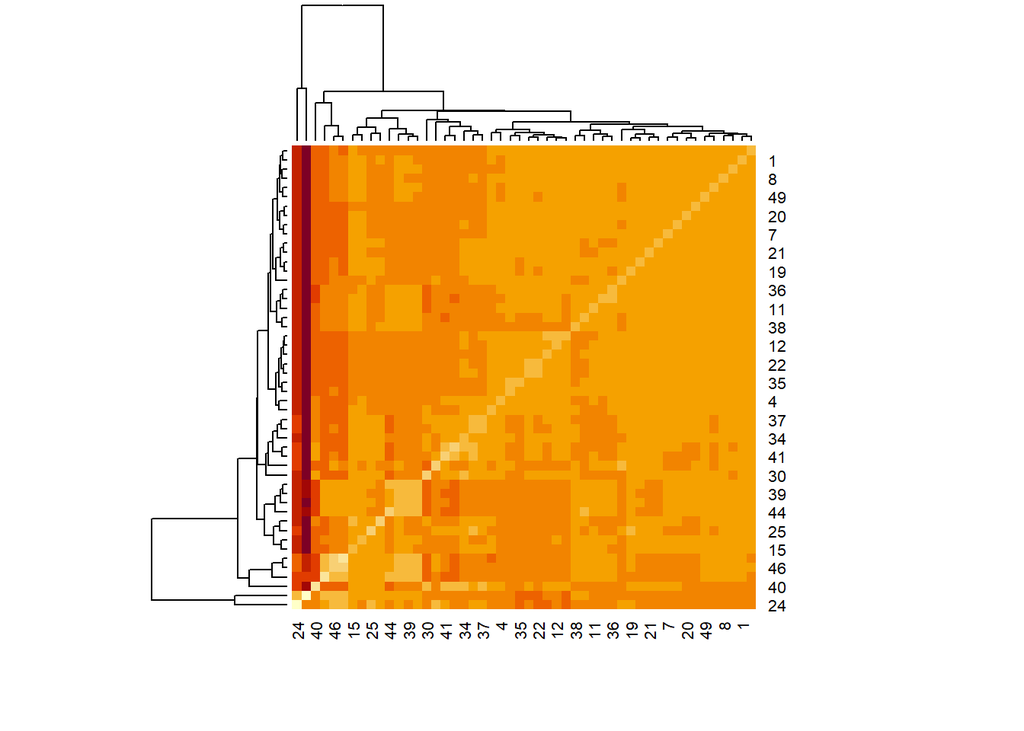

```r
# Visualisasi Matrix
heatmap(matrix_euclid[1:50, 1:50])
```

```r
# Mencari Pasangan Yang Paling Dekat
terdekat <- which(matrix_euclid == min(matrix_euclid[matrix_euclid > 0]), arr.ind = TRUE)
print(terdekat)
```

```
##    row col
## 99  99  98
## 98  98  99
```

Berdasarkan hasil perhitungan, pasangan observasi yang paling dekat adalah data ke-98 dan ke-99, dengan nilai jarak yang sangat kecil. Hal ini menunjukkan bahwa kedua pelanggan tersebut memiliki karakteristik pembelian yang sangat mirip dibandingkan pasangan lainnya.

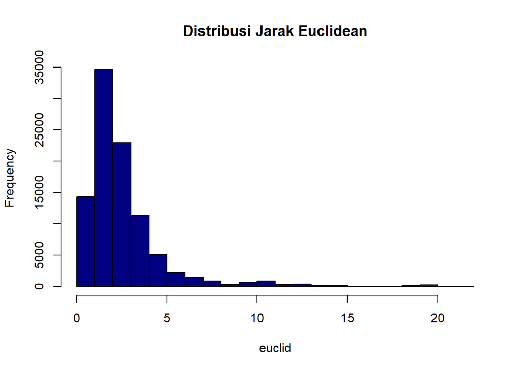

```r
# Distribusi Jarak
hist(euclid, main = "Distribusi Jarak Euclidean", col = "navy")
```

```r
mean(euclid)
```

```
## [1] 2.581904
```

Berdasarkan hasil histogram, distribusi condong ke arah kanan yang menunjukkan bahwa sebagian besar pelanggan memiliki jarak yang rekatif kecil hingga sedang (pola belanja pelanggan tidak terlalu berbeda jauh). Namun, adanya nilai jarak yang besar oada bagian ekor kanan menunjukkan terdapat beberapa pelanggan dengan pola pembelian yang sangat berbeda .

Selain itu, nilai rata-rata jarak sebesar 2.582 menunjukkan bahwa secara umum tingkat kemiripan antar pelanggan berada pada kategori sedang. Artinya, sebagian besar pelanggan tidak terlalu mirip satu sama lain, namun juga tidak sepenuhnya berbeda.

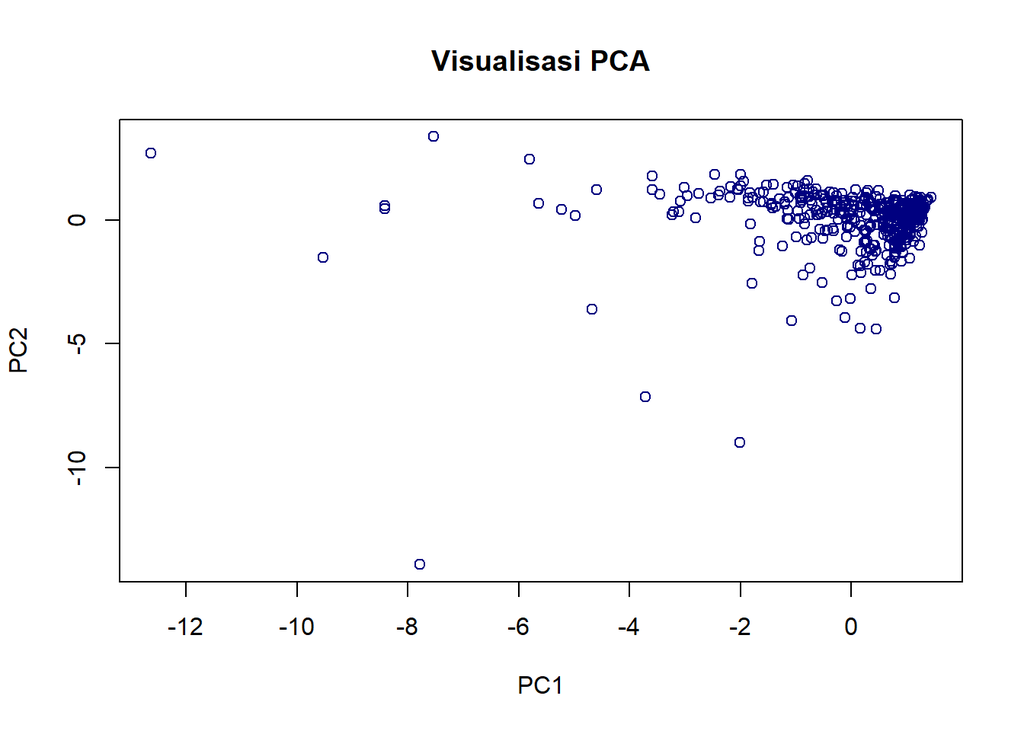

```r
# Visualisasi PCA
pca <- prcomp(data_scaled)
plot(pca$x[, 1:2], col = "navy", main = "Visualisasi PCA")
```

Berdasarkan visualisasi PCA, terlihat bahwa sebagian besar data terkonsentrasi di area pusat, sementara beberapa titik tersebar cukup jauh dari pusat distribusi. Hal ini menunjukkan bahwa mayoritas pelanggan memiliki pola pembelian yang relatif mirip, namun terdapat beberapa pelanggan dengan karakteristik yang sangat berbeda (outlier atau segmen khusus). Selain itu, tidak terlihat pemisahan cluster yang sangat tegas, melainkan pola yang cenderung menyebar dan sedikit tumpang tindih.

### Kesimpulan Model 1

Secara keseluruhan, perhitungan jarak Euclidean menunjukkan bahwa data memiliki tingkat keragaman yang cukup tinggi, ditandai dengan rentang jarak yang lebar serta adanya beberapa observasi yang sangat mirip dan sangat berbeda. Kondisi ini mengindikasikan bahwa data memiliki struktur yang tidak homogen dan berpotensi membentuk beberapa kelompok. Oleh karena itu, hasil ini menjadi dasar yang kuat untuk melanjutkan analisis ke metode clustering guna mengidentifikasi kelompok pelanggan secara lebih jelas.

# Model 2

## Partitioning (K-Means)

### Penyelesaian

```r
# Package Yang Digunakan
library(cluster)
library(factoextra)
```

```r
# Data
kmeans_whole <- data_scaled
```

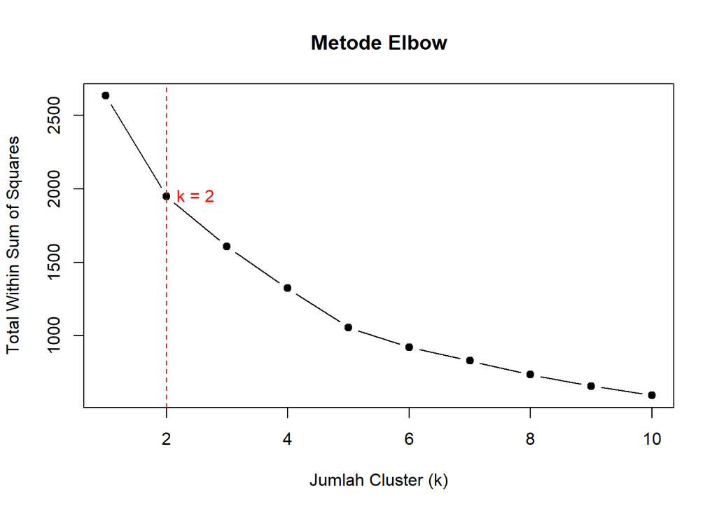

```r
# Menentukan Jumlah Klaster
# Metode Elbow
wss <- numeric(10)

for (k in 1:10) {
  kmeans_model <- kmeans(kmeans_whole, centers = k, nstart = 25)
  wss[k] <- kmeans_model$tot.withinss
}

plot(1:10, wss, type="b", pch=19,
     xlab="Jumlah Cluster (k)",
     ylab="Total Within Sum of Squares",
     main="Metode Elbow")
abline(v = 2, col = "red", lty = 2)
text(2, wss[2], labels = "k = 2", pos = 4, col = "red")
```

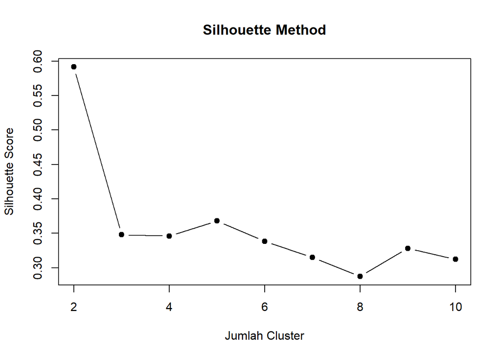

```r
# Metode Silhoutte
sil_width <- numeric(10)
d <- dist(kmeans_whole)

for (k in 2:10) {
  km <- kmeans(kmeans_whole, centers = k, nstart = 25)
  ss <- silhouette(km$cluster, d)
  sil_width[k] <- mean(ss[, 3])
}

plot(2:10, sil_width[2:10], type="b", pch=19,
     xlab="Jumlah Cluster",
     ylab="Silhouette Score",
     main="Silhouette Method")
```

```r
k_terbaik <- which.max(sil_width)
print(k_terbaik)
```

```
## [1] 2
```

Berdasarkan hasil metode Silhouette, nilai silhouette tertinggi berada pada k = 2, yang berarti pemisahan antar cluster paling baik dan struktur cluster paling jelas pada jumlah tersebut.

Kedua metode menunjukkan bahwa jumlah cluster optimal adalah k = 2, sehingga data dapat dibagi menjadi dua kelompok utama dengan karakteristik yang berbeda.

```r
# K-Means
set.seed(165)
k_means <- kmeans(kmeans_whole, centers = 2, nstart = 25)
```

```r
# Hasil Clustering
k_means$cluster
```

```
##   [1] 2 2 2 2 2 2 2 2 2 2 2 2 2 2 2 2 2 2 2 2 2 2 2 1 2 2 2 2 1 2 2 2 2 2 2 2 2
##  [38] 2 2 2 2 2 2 1 2 1 1 1 2 1 2 2 2 2 2 2 1 2 2 2 2 1 2 2 2 1 2 2 2 2 2 2 2 2
##  [75] 2 2 2 1 2 2 2 2 2 2 2 1 1 2 2 2 2 2 1 2 2 2 2 2 2 2 2 2 2 2 2 2 2 2 2 2 2
## [112] 2 2 2 2 2 2 2 2 2 2 2 2 2 2 2 2 2 2 2 2 2 2 2 2 2 2 2 2 2 2 2 2 2 2 1 2 2
## [149] 2 2 2 2 2 2 2 1 2 2 2 2 2 2 2 1 2 1 2 2 2 2 2 1 2 2 2 2 2 2 2 2 2 1 2 1 2
## [186] 2 2 2 2 2 2 2 2 2 2 2 2 2 2 2 1 1 2 2 2 1 2 2 2 1 2 1 2 2 2 2 1 2 2 2 2 2
## [223] 2 2 2 2 2 2 2 2 2 2 2 2 2 2 2 2 2 2 2 2 2 2 2 2 2 2 2 2 2 1 2 2 2 2 2 2 2
## [260] 2 2 2 2 2 2 2 2 2 2 2 2 2 2 2 2 2 2 2 2 2 2 2 2 2 2 2 2 2 2 2 2 2 2 2 2 2
## [297] 2 2 2 2 2 1 2 2 1 2 1 2 2 1 2 2 1 2 2 2 2 2 2 1 2 2 2 2 2 1 2 2 2 2 2 1 2
## [334] 1 2 2 2 2 2 2 2 2 2 1 2 2 2 2 2 1 2 1 2 2 2 2 2 2 2 2 2 2 2 2 2 2 2 2 2 2
## [371] 2 2 2 2 2 2 2 2 2 2 2 2 2 2 2 2 2 2 2 2 2 2 2 2 2 2 2 2 2 2 2 2 2 2 2 2 2
## [408] 2 2 2 2 2 2 2 2 2 2 2 2 2 2 2 2 2 2 2 2 2 2 2 2 2 2 2 2 2 2 1 2 2
```

```r
table(k_means$cluster)
```

```
##
##   1   2
##  41 399
```

```r
prop.table(table(k_means$cluster))
```

```
##
##          1          2
## 0.09318182 0.90681818
```

Berdasarkan hasil K-Means clustering, data terbagi menjadi dua cluster dengan distribusi yang tidak seimbang. Cluster 1 terdiri dari 41 observasi (9.3%), sedangkan Cluster 2 mendominasi dengan 399 observasi (90.7%). Hal ini menunjukkan bahwa sebagian besar pelanggan memiliki karakteristik yang mirip, sementara sebagian kecil lainnya memiliki pola yang berbeda. Perbedaan ini mengindikasikan adanya kelompok minoritas dengan karakteristik khusus, yang kemungkinan dipengaruhi oleh keberadaan outlier dalam data.

```r
# Sentroid
k_means$centers
```

```
##         Fresh       Milk    Grocery      Frozen Detergents_Paper Delicassen
## 1  0.05283636  2.0659269  2.2407190  0.32219794        2.2585338  0.8039597
## 2 -0.00542930 -0.2122882 -0.2302493 -0.03310806       -0.2320799 -0.0826124
```

Berdasarkan nilai sentroid, terlihat perbedaan karakteristik yang cukup jelas antara kedua cluster. Cluster 1 memiliki nilai yang jauh lebih tinggi pada variabel Milk (2.07), Grocery (2.24), dan Detergents_Paper (2.26), serta cukup tinggi pada Delicassen (0.80). Hal ini menunjukkan bahwa cluster ini merepresentasikan pelanggan dengan tingkat pembelian yang tinggi, khususnya pada produk kebutuhan rumah tangga. Sebaliknya, Cluster 2 memiliki nilai negatif pada hampir semua variabel, yang menunjukkan bahwa pengeluaran pelanggan pada cluster ini cenderung berada di bawah rata-rata.

CLuster 1 dapat diinterpretasikan sebagai kelompok pelanggan dengan intensitas belanja tinggi (high spender), sedangkan Cluster 2 merupakan kelompok pelanggan dengan pola pembelian yang lebih rendah dan lebih umum (regular customer).

```r
# Evalusi Model
k_means$tot.withinss
```

```
## [1] 1949.348
```

```r
k_means$totss
```

```
## [1] 2634
```

```r
k_means$betweenss
```

```
## [1] 684.6521
```

```r
k_means$betweenss / k_means$totss
```

```
## [1] 0.2599287
```

Berdasarkan hasil evaluasi K-Means Clustering, diperoleh nilai `between sum of squares` sebesar 684.65 dari total variasi data sebesar 2634, sehingga proporsi variasi yang dapat dijelaskan oleh model clustering adalah sekitar 25.99%. Hal ini menunjukkan bahwa model K-Means mampu menjelaskan sebagian variasi data, namun masih terdapat variasi yang cukup besar di dalam cluster.

```r
# Stabilitas Hasil K-Means
set.seed(321)
k1 <- kmeans(kmeans_whole, centers = 2, nstart = 25)

set.seed(123)
k2 <- kmeans(kmeans_whole, centers = 2, nstart = 25)

table(k1$cluster, k2$cluster)
```

```
##
##       1   2
##   1   0 399
##   2  41   0
```

Berdasarkan uji stabilitas pada K-Means Clustering dengan dua nilai seed yang berbeda, diperoleh hasil bahwa seluruh anggota cluster tetap konsisten, hanya terjadi pertukaran label antara cluster 1 dan 2.

```r
# Skor Silhoutte
sill_score <- silhouette(k_means$cluster, d)
mean(sill_score[, 3])
```

```
## [1] 0.5914656
```

Berdasarkan hasil Silhouette Score, diperoleh nilai rata-rata silhouette sebesar 0.59. Nilai ini menunjukkan bahwa kualitas clustering tergolong cukup baik, di mana sebagian besar data sudah berada pada cluster yang tepat dan memiliki pemisahan yang cukup jelas antar cluster.

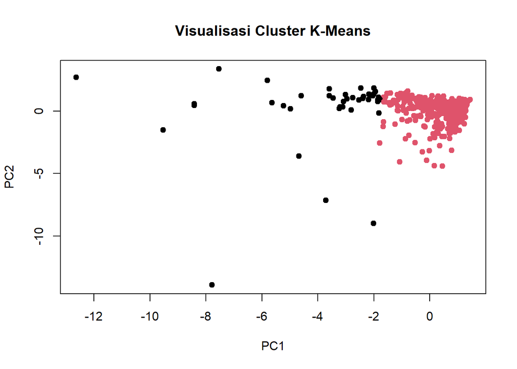

```r
# PCA
pca <- prcomp(kmeans_whole)

plot(pca$x[,1:2],
     col = k_means$cluster,
     pch = 19,
     xlab = "PC1",
     ylab = "PC2",
     main = "Visualisasi Cluster K-Means")
```

Berdasarkan visualisasi PCA, terlihat bahwa data terbagi menjadi dua kelompok utama sesuai dengan hasil K-Means (k = 2). Sebagian besar observasi terkonsentrasi dalam satu cluster yang mendominasi area pusat, sementara cluster lainnya terdiri dari sejumlah kecil titik yang tersebar lebih jauh dari pusat. Hal ini menunjukkan bahwa mayoritas pelanggan memiliki pola pembelian yang relatif seragam, sedangkan sebagian kecil lainnya memiliki karakteristik yang berbeda secara signifikan.

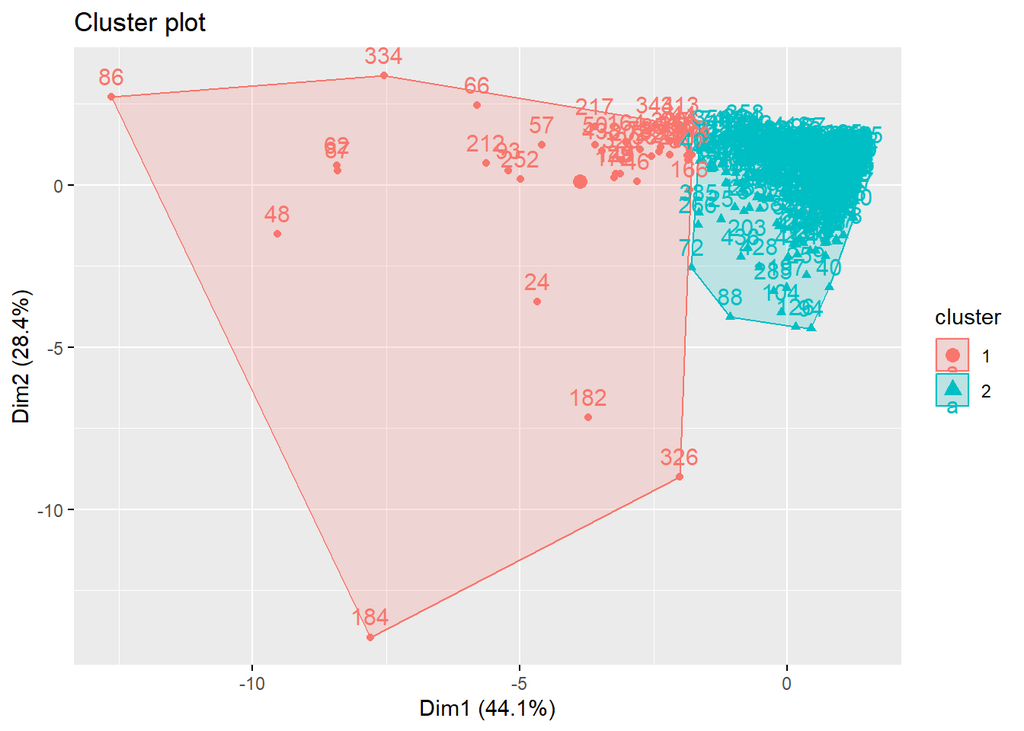

```r
# Visualisasi
fviz_cluster(k_means, data = kmeans_whole)
```

Berdasarkan visualisasi fviz_cluster, terlihat bahwa dua cluster yang terbentuk memiliki batas yang relatif tegas dengan sedikit tumpang tindih. Cluster besar mendominasi sebagian besar area dan merepresentasikan pelanggan dengan pola pembelian yang cenderung normal atau di bawah rata-rata, sedangkan cluster kecil berada pada area yang lebih terpisah dan menunjukkan pelanggan dengan nilai pembelian yang lebih tinggi.

### Kesimpulan Model 2

Berdasarkan hasil analisis, model K-Means dengan k = 2 mampu membagi data menjadi dua kelompok utama, yaitu pelanggan dengan pembelian tinggi (minoritas) dan pelanggan dengan pembelian rendah/normal (mayoritas). Meskipun kualitas clustering tergolong cukup baik (silhouette 0.59), distribusi cluster yang tidak seimbang menunjukkan bahwa model ini dipengaruhi oleh outlier dan kurang mampu menangkap kompleksitas data.

# Model 3

## Model Based Clustering (GMM)

### Penyelesaian

```r
# Package
library(mclust)
library(factoextra)
```

```r
# Data
data_gmm <- data_scaled
```

```r
# Menentukan Jumlah Klaster
model_gmm <- Mclust(data_gmm)
summary(model_gmm)
```

```
## ----------------------------------------------------
## Gaussian finite mixture model fitted by EM algorithm
## ----------------------------------------------------
##
## Mclust VVE (ellipsoidal, equal orientation) model with 7 components:
##
##  log-likelihood   n  df       BIC       ICL
##       -1262.255 440 105 -3163.621 -3263.066
##
## Clustering table:
##  1  2  3  4  5  6  7
## 69 51 71 88 78 18 65
```

```r
model_gmm$G
```

```
## [1] 7
```

Berdasarkan hasilGaussian Mixture Model (GMM), diperoleh jumlah cluster optimal sebanyak 7 cluster dengan model terbaik bertipe VVE (ellipsoidal, equal orientation). Hal ini menunjukkan bahwa data memiliki struktur yang lebih kompleks dan tidak dapat direpresentasikan hanya dengan sedikit kelompok seperti pada K-Means.

Distribusi anggota tiap cluster relatif bervariasi, dengan jumlah terbesar pada cluster 4 (88 observasi) dan paling kecil pada cluster 6 (18 observasi). Meskipun terdapat perbedaan ukuran cluster, distribusinya lebih tersebar dibandingkan hasil K-Means, yang sebelumnya sangat didominasi oleh satu cluster.

```r
# Jenis Model
model_gmm$modelName
```

```
## [1] "VVE"
```

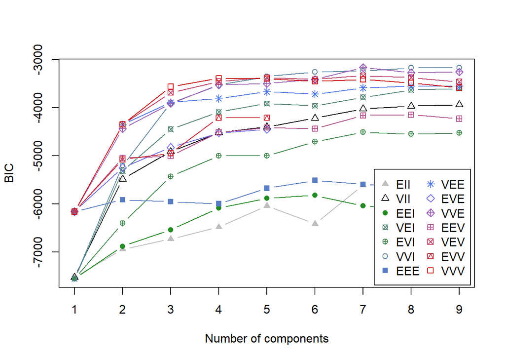

```r
# Visualisasi
plot(model_gmm, what = "BIC")
```

Berdasarkan hasil plot BIC menunjukkan bahwa nilai BIC meningkat (semakin mendekati nol) seiring bertambahnya jumlah komponen, yang menandakan model semakin baik dalam menyesuaikan data. Namun, peningkatan tersebut mulai melambat setelah sekitar 6–7 komponen, sehingga perbaikan model tidak lagi signifikan.

```r
# Hasil Klaster
model_gmm$classification
```

```
##   [1] 4 4 2 3 3 4 4 4 4 2 2 7 4 4 4 7 1 3 4 4 4 5 3 6 4 4 5 7 2 3 4 4 5 3 7 1 3
##  [38] 4 1 3 3 4 4 1 4 2 2 6 4 2 5 1 3 1 5 4 2 1 7 4 4 6 2 2 5 2 1 4 3 7 3 6 3 3
##  [75] 4 5 3 2 7 1 7 1 4 5 4 6 6 6 3 3 5 5 2 6 4 1 1 7 7 5 2 1 4 3 7 4 1 2 1 2 5
## [112] 4 3 5 5 5 7 4 5 5 5 7 5 4 5 3 5 4 1 3 5 7 7 7 7 7 2 1 3 4 4 4 3 5 4 6 7 7
## [149] 5 5 5 1 5 1 7 1 1 5 1 1 1 4 5 2 4 2 4 1 7 5 1 2 1 1 4 1 3 4 4 3 4 6 1 6 1
## [186] 4 5 2 2 1 3 7 7 1 7 3 3 1 3 7 2 2 6 7 1 1 7 2 1 2 5 2 5 1 1 1 2 5 2 7 5 4
## [223] 5 3 7 4 4 7 1 5 3 1 5 1 3 1 7 3 7 3 3 5 5 4 4 1 7 5 4 3 7 2 3 6 2 5 4 2 3
## [260] 3 4 5 5 3 1 6 2 3 2 5 5 1 1 3 7 7 3 3 5 4 7 4 3 3 3 5 7 5 7 5 5 4 5 1 4 4
## [297] 5 4 4 7 4 2 1 1 1 1 2 5 7 2 3 3 2 5 4 2 5 1 7 2 1 4 5 4 3 6 5 7 3 5 3 2 3
## [334] 6 3 4 7 5 3 3 1 1 1 2 7 1 2 4 7 2 7 2 7 1 3 7 5 1 2 1 5 7 7 7 7 4 7 7 5 7
## [371] 3 5 3 4 7 7 2 3 7 1 5 3 3 5 2 5 4 5 7 5 5 5 1 3 7 5 4 5 5 7 5 3 4 4 3 7 3
## [408] 2 4 4 4 3 1 3 5 4 1 4 1 4 1 4 5 4 4 3 4 6 4 4 2 3 4 1 4 6 3 2 5 7
```

```r
table(model_gmm$classification)
```

```
##
##  1  2  3  4  5  6  7
## 69 51 71 88 78 18 65
```

```r
prop.table(table(model_gmm$classification))
```

```
##
##          1          2          3          4          5          6          7
## 0.15681818 0.11590909 0.16136364 0.20000000 0.17727273 0.04090909 0.14772727
```

Berdasarkan hasil GMM, data terbagi ke dalam 7 cluster dengan distribusi yang relatif lebih merata dibandingkan K-Means. Cluster 4 memiliki proporsi terbesar (20%), sedangkan cluster 6 merupakan yang paling kecil (4.1%).

Sebagian besar cluster memiliki proporsi yang cukup seimbang, berada pada kisaran 11%–20%, yang menunjukkan bahwa data tidak lagi didominasi oleh satu kelompok besar, melainkan tersebar ke beberapa kelompok dengan ukuran yang lebih proporsional. Hal tersebut mengindikasikan bahwa GMM mampu menangkap struktur data yang lebih kompleks dan membentuk segmentasi yang lebih detail.

```r
# Parameter
model_gmm$parameters
```

```
## $pro
## [1] 0.14659378 0.12686462 0.16193044 0.20032097 0.18220190 0.04197336 0.14011492
##
## $mean
##                         [,1]       [,2]       [,3]        [,4]        [,5]
## Fresh            -0.81656985 -0.5037589  0.8498186  0.04259082  0.19511900
## Milk              0.08643382  1.0058150 -0.3004358 -0.01557313 -0.58998787
## Grocery           0.23191461  1.1373689 -0.3744975 -0.02067481 -0.61399799
## Frozen           -0.50557366 -0.1324153  0.8180933 -0.39053556  0.08289279
## Detergents_Paper  0.30430857  1.1821789 -0.4625321 -0.05915590 -0.52612561
## Delicassen       -0.20499178  0.1783473  0.1247140 -0.03801934 -0.24253790
##                      [,6]       [,7]
## Fresh            1.481181 -0.4300134
## Milk             2.437386 -0.5945978
## Grocery          2.099521 -0.6405980
## Frozen           1.879630 -0.4091397
## Detergents_Paper 1.473743 -0.5269609
## Delicassen       2.240191 -0.3924768
##
## $variance
## $variance$modelName
## [1] "VVE"
##
## $variance$d
## [1] 6
##
## $variance$G
## [1] 7
##
## $variance$sigma
## , , 1
##
##                          Fresh         Milk      Grocery        Frozen
## Fresh             0.0114910715 -0.001245423 -0.007237771  0.0009663451
## Milk             -0.0012454230  0.305813857  0.171154074 -0.0172032174
## Grocery          -0.0072377712  0.171154074  0.340294035 -0.0187053452
## Frozen            0.0009663451 -0.017203217 -0.018705345  0.0133005784
## Detergents_Paper -0.0061037913  0.190639555  0.291590294 -0.0213894125
## Delicassen        0.0031119940 -0.022716765  0.009239808  0.0122382738
##                  Detergents_Paper   Delicassen
```

[output cut: 126 more lines]

```
## Grocery           0.029317788 -0.33609436  0.7250219963  0.024574010
## Frozen           -0.047820493 -0.02990340 -0.0006959448  0.980105458
## Detergents_Paper  0.002609268 -0.30666807 -0.6853584631  0.040589359
## Delicassen       -0.050463604 -0.25139437 -0.0605056251 -0.189190958
##                  Detergents_Paper  Delicassen
## Fresh               -0.0114374428  0.06299006
## Milk                 0.4674585066  0.22774461
## Grocery              0.5988374120 -0.03624949
## Frozen              -0.0425923070  0.18546614
## Detergents_Paper     0.6487921552 -0.11684565
## Delicassen          -0.0003437744  0.94593870
##
##
## $Vinv
## NULL
```

Perbedaan nilai mean ini menunjukkan bahwa GMM mampu membedakan pola pengeluaran pelanggan secara lebih spesifik. Selain itu, model VVE menunjukkan bahwa cluster berbentuk elips dengan orientasi yang sama, sehingga lebih fleksibel dalam menangkap struktur data.

```r
# Evaluasi Model
model_gmm$bic
```

```
## [1] -3163.621
```

```r
model_gmm$loglik
```

```
## [1] -1262.255
```

Berdasarkan hasil evaluasi model, nilai log-likelihood sebesar -1262.255 dan BIC sebesar -3163.621 menunjukkan model yang dipilih merupakan yang paling optimal di antara kandidat model lainnya, sehingga hasil clustering ini dapat dianggap cukup baik dalam merepresentasikan struktur data.

```r
# Probabilitas
model_gmm$z
```

```
##                 [,1]          [,2]          [,3]          [,4]          [,5]
##   [1,]  2.372513e-14  4.116612e-03  1.825821e-05  9.958605e-01  3.444862e-39
##   [2,]  3.288122e-04  3.555803e-02  1.722677e-06  9.641082e-01  6.251409e-45
##   [3,]  1.854971e-16  9.956726e-01  3.542448e-05  8.843230e-05  2.192469e-65
##   [4,]  3.256221e-41  1.400169e-03  9.471901e-01  4.448921e-08  5.139534e-02
##   [5,]  3.759574e-56  6.224062e-04  9.273216e-01  7.118780e-02  2.696655e-25
##   [6,]  5.703484e-07  8.428588e-03  1.162254e-03  9.904062e-01  5.938227e-24
##   [7,]  1.720973e-13  1.834930e-03  2.434068e-03  9.957294e-01  2.917258e-12
##   [8,]  8.131708e-05  1.522543e-02  3.689823e-04  9.843225e-01  4.895577e-25
##   [9,]  3.062273e-02  6.441739e-03  1.348324e-02  9.491666e-01  2.441853e-07
##  [10,]  5.072756e-02  7.268692e-01  7.082471e-20  2.223445e-01 1.366177e-130
##  [11,]  6.380678e-11  9.935712e-01  2.833217e-07  6.308255e-03  7.149804e-56
##  [12,]  5.066022e-17  6.539035e-04  2.373621e-02  3.744491e-01  1.500845e-01
##  [13,] 2.937992e-106  9.874376e-09  1.389839e-07  9.968935e-01  2.721271e-73
##  [14,]  8.097277e-52  1.059815e-02  9.061229e-09  9.858228e-01  5.979339e-70
```

[output cut: 867 more lines]

Probabilitas posterior menunjukkan peluang setiap observasi masuk ke masing-masing klaster (1–7). Dari hasil tersebut, terlihat bahwa sebagian besar observasi memiliki probabilitas yang sangat tinggi (mendekati 1) pada satu klaster tertentu dan sangat kecil pada klaster lain.

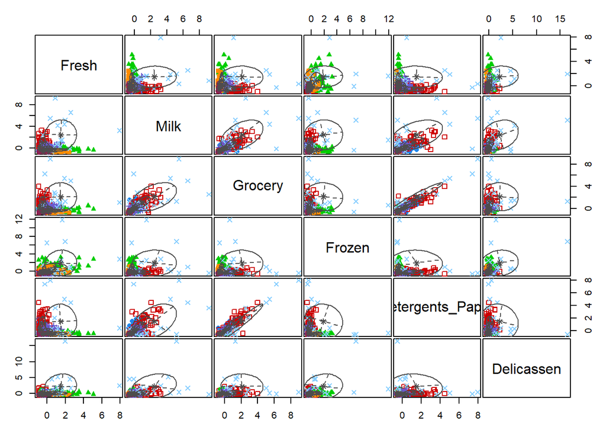

```r
# Visualisasi Klaster
plot(model_gmm, what = "classification")
```

Berdasarkan hasil visualisasi pairplot, menunjukkan bahwa model GMM mampu mengidentifikasi beberapa kelompok pelanggan dengan pola pembelian yang berbeda. Terlihat bahwa variabel Milk, Grocery, dan Detergents_Paper memiliki korelasi positif yang kuat, sehingga menjadi faktor utama dalam membedakan cluster—kelompok dengan nilai tinggi pada ketiga variabel ini cenderung merepresentasikan pelanggan seperti retailer atau toko kebutuhan sehari-hari. Sementara itu, variabel Fresh dan Frozen memiliki pola yang lebih menyebar dan tidak terlalu berkorelasi, yang mengindikasikan segmen pelanggan dengan kebutuhan spesifik seperti bisnis makanan. Beberapa cluster juga terlihat saling tumpang tindih, terutama pada nilai yang rendah, yang menunjukkan adanya kemiripan karakteristik antar pelanggan serta mencerminkan sifat probabilistik dari GMM.

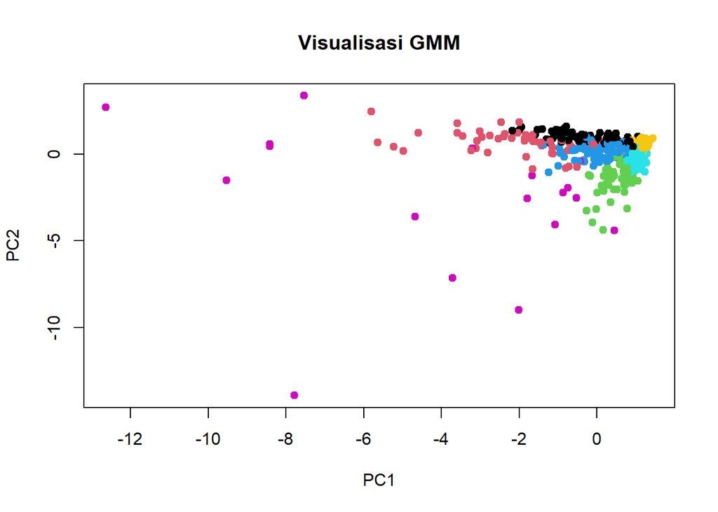

```r
# PCA
pca <- prcomp(data_gmm)

plot(pca$x[, 1:2],
     col = model_gmm$classification,
     pch = 19,
     xlab = "PC1",
     ylab = "PC2",
     main = "Visualisasi GMM")
```

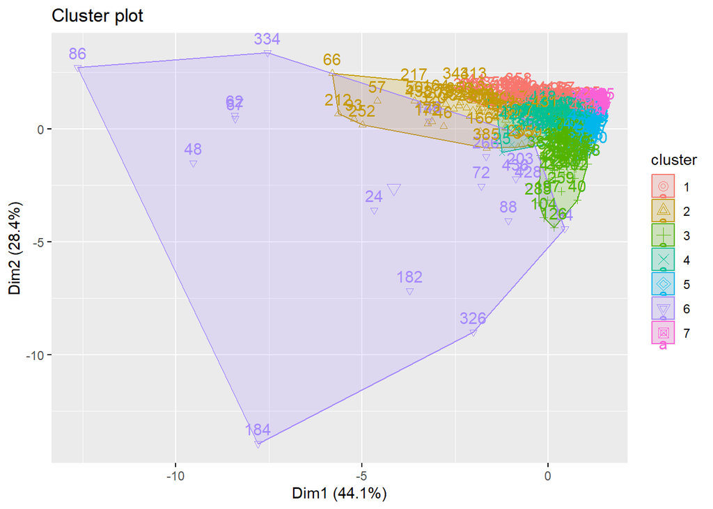

```r
fviz_cluster(list(data = data_gmm, cluster = model_gmm$classification))
```

Berdasarkan visualisasi cluster plot hasil Gaussian Mixture Model (GMM), terlihat bahwa data pelanggan terbagi ke dalam beberapa kelompok dengan pola penyebaran yang cukup kompleks. Sebagian besar observasi terkonsentrasi pada area tertentu (terutama di sisi kanan plot), yang menunjukkan adanya kelompok pelanggan utama dengan karakteristik pembelian yang relatif mirip. Di sisi lain, terdapat beberapa titik yang tersebar jauh dari pusat distribusi (di bagian kiri atau atas), yang mengindikasikan adanya segmen pelanggan khusus dengan pola pembelian yang lebih ekstrem, baik dalam jumlah yang sangat tinggi maupun sangat rendah. Selain itu, terlihat adanya tumpang tindih (overlapping) antar beberapa cluster, khususnya di area tengah. Hal ini menunjukkan bahwa batas antar kelompok tidak bersifat tegas, melainkan bersifat probabilistik, di mana satu pelanggan dapat memiliki kemiripan dengan lebih dari satu cluster.

### Kesimpulan Model 3

Secara keseluruhan, model Gaussian Mixture Model dengan 7 cluster mampu mengelompokkan data secara optimal, yang didukung oleh nilai BIC dan log-likelihood yang diperoleh. Visualisasi dan probabilitas keanggotaan menunjukkan bahwa sebagian besar observasi memiliki kecenderungan kuat pada satu cluster, meskipun tetap terdapat beberapa overlap yang mencerminkan sifat probabilistik model. Segmentasi yang terbentuk memperlihatkan perbedaan pola pembelian yang jelas, terutama pada variabel Milk, Grocery, dan Detergents_Paper, sehingga hasil ini dapat digunakan sebagai dasar dalam memahami karakteristik pelanggan dan pengambilan keputusan yang lebih terarah.

# Model 4

## Fuzzy Clustering (Fuzzy C-Means)

### Penyelesaian

```r
# Package
library(e1071)
library(cluster)
library(factoextra)
```

```r
# Data
data_fuzzy <- data_numerik
```

```r
# Transformasi Log
fuzzy_log <- log1p(data_fuzzy)
```

```r
# Eksplorasi Data
str(fuzzy_log)
```

```
## 'data.frame':    440 obs. of  6 variables:
##  $ Fresh           : num  9.45 8.86 8.76 9.49 10.03 ...
##  $ Milk            : num  9.18 9.19 9.08 7.09 8.6 ...
##  $ Grocery         : num  8.93 9.17 8.95 8.35 8.88 ...
##  $ Frozen          : num  5.37 7.47 7.79 8.76 8.27 ...
##  $ Detergents_Paper: num  7.89 8.1 8.17 6.23 7.48 ...
##  $ Delicassen      : num  7.2 7.48 8.97 7.49 8.55 ...
```

```r
summary(fuzzy_log)
```

```
##      Fresh             Milk           Grocery           Frozen
##  Min.   : 1.386   Min.   : 4.025   Min.   : 1.386   Min.   : 3.258
##  1st Qu.: 8.048   1st Qu.: 7.336   1st Qu.: 7.675   1st Qu.: 6.611
##  Median : 9.048   Median : 8.196   Median : 8.467   Median : 7.331
##  Mean   : 8.733   Mean   : 8.122   Mean   : 8.442   Mean   : 7.303
##  3rd Qu.: 9.737   3rd Qu.: 8.881   3rd Qu.: 9.274   3rd Qu.: 8.176
##  Max.   :11.628   Max.   :11.205   Max.   :11.438   Max.   :11.016
##  Detergents_Paper   Delicassen
##  Min.   : 1.386   Min.   : 1.386
##  1st Qu.: 5.552   1st Qu.: 6.014
##  Median : 6.706   Median : 6.874
##  Mean   : 6.792   Mean   : 6.671
##  3rd Qu.: 8.275   3rd Qu.: 7.507
##  Max.   :10.617   Max.   :10.778
```

```r
cor(fuzzy_log)
```

```
##                        Fresh        Milk    Grocery      Frozen
## Fresh             1.00000000 -0.02109638 -0.1329889  0.38625790
## Milk             -0.02109638  1.00000000  0.7611276 -0.05522851
## Grocery          -0.13298890  0.76112760  1.0000000 -0.16452522
## Frozen            0.38625790 -0.05522851 -0.1645252  1.00000000
## Detergents_Paper -0.15870598  0.67872480  0.7971412 -0.21277086
## Delicassen        0.25644186  0.34231006  0.2399975  0.25631819
##                  Detergents_Paper Delicassen
## Fresh                  -0.1587060  0.2564419
## Milk                    0.6787248  0.3423101
## Grocery                 0.7971412  0.2399975
## Frozen                 -0.2127709  0.2563182
## Detergents_Paper        1.0000000  0.1675729
## Delicassen              0.1675729  1.0000000
```

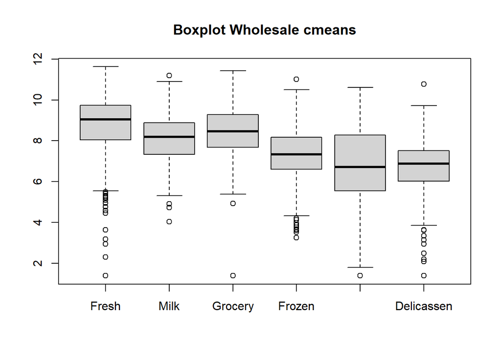

```r
boxplot(fuzzy_log, main = "Boxplot Wholesale cmeans")
```

Berdasarkan hasil tersebut, data terdiri dari 440 observasi dengan 6 variabel numerik yang telah ditransformasi log, sehingga distribusi menjadi lebih stabil dan pengaruh outlier berkurang. Nilai rata-rata dan median yang relatif dekat menunjukkan data sudah cukup seimbang, meskipun variasi masih terlihat pada beberapa variabel seperti Fresh, Milk, dan Grocery.

Selain itu, masih terdapat outlier pada beberapa variabel seperti Fresh, Frozen, dan Delicassen, yang mengindikasikan adanya pelanggan dengan pola pembelian yang berbeda dari mayoritas. Hal ini menunjukkan data cukup heterogen dan mendukung penggunaan metode clustering.

Berdasarkan hasil Boxplot, menunjukkan bahwa seluruh variabel masih memiliki variasi yang cukup besar meskipun sudah ditransformasi log. Variabel Fresh, Milk, dan Grocery memiliki median lebih tinggi, yang menandakan nilai pembelian cenderung lebih besar, sedangkan Detergents_Paper dan Delicassen relatif lebih rendah. Selain itu, masih terdapat outlier pada beberapa variabel seperti Fresh, Frozen, dan Delicassen, yang mengindikasikan adanya pelanggan dengan pola pembelian yang berbeda dari mayoritas. Hal ini menunjukkan data cukup heterogen dan mendukung penggunaan metode clustering.

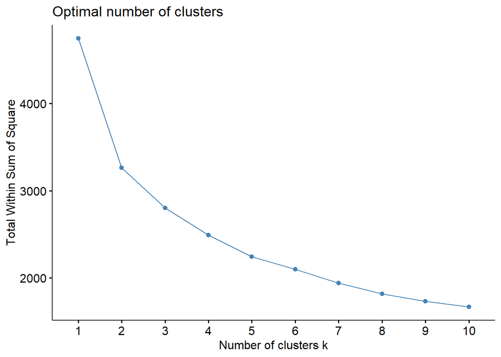

```r
# Menentukan Jumlah Cluster
fviz_nbclust(fuzzy_log, kmeans, method = "wss")
```

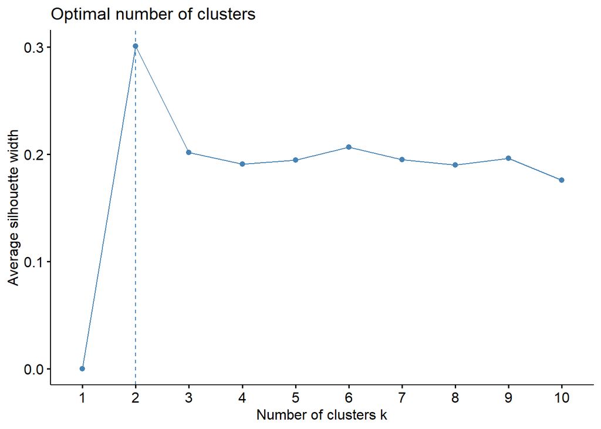

```r
fviz_nbclust(fuzzy_log, kmeans, method = "silhouette")
```

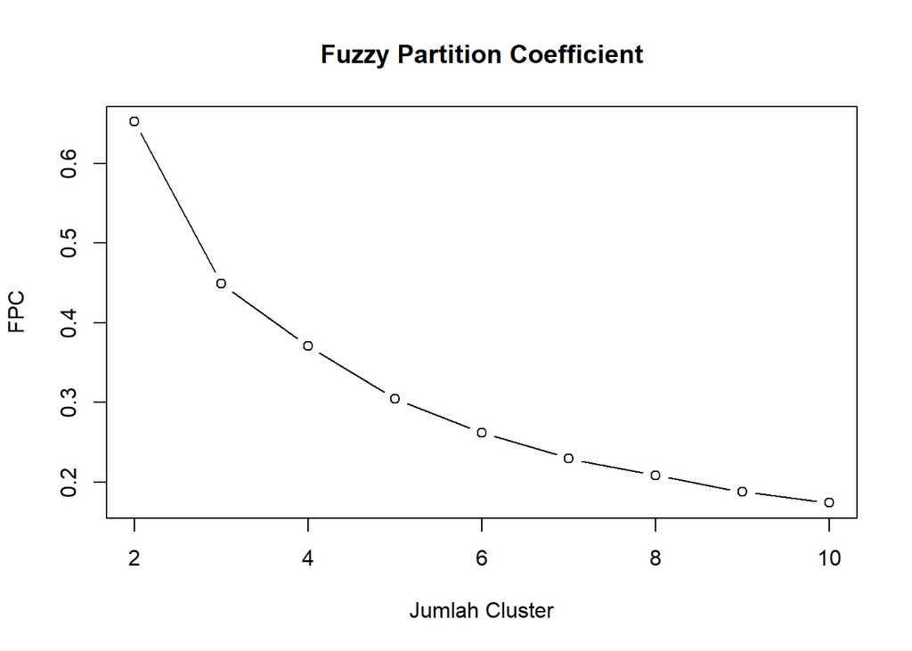

```r
fpc_val <- numeric(9)

for(i in 1:9) {
  k <- i + 1
  model <- cmeans(fuzzy_log, centers = k, m = 2)
  fpc_val[i] <- sum(model$membership^2)/nrow(fuzzy_log)
}

plot(2:10, fpc_val, type = "b",
     xlab = "Jumlah Cluster",
     ylab = "FPC",
     main = "Fuzzy Partition Coefficient")
```

Berdasarkan hasil grafik `Fuzzy Partition Coefficient` (FPC), terlihat bahwa nilai FPC tertinggi berada pada jumlah cluster 2, kemudian terus menurun seiring bertambahnya jumlah cluster. Hal ini menunjukkan bahwa pembagian data paling optimal terjadi saat jumlah cluster sedikit, karena nilai FPC yang lebih tinggi menandakan keanggotaan yang lebih jelas.

Hasil ini juga konsisten dengan metode Elbow dan Silhouette, yang sama-sama menunjukkan bahwa jumlah cluster optimal adalah 2. Pada metode Elbow terlihat adanya titik “siku” pada cluster ke-2, sedangkan nilai Silhouette tertinggi juga diperoleh pada jumlah cluster tersebut.

```r
# Cmeans
set.seed(165)
model_fcm <- cmeans(
  fuzzy_log,
  centers = 2,
  m = 2,
  iter.max = 100
)
```

```r
# Membership
head(model_fcm$membership)
```

```
##              1          2
## [1,] 0.7883091 0.21169093
## [2,] 0.9245865 0.07541345
## [3,] 0.7550092 0.24499078
## [4,] 0.2173771 0.78262288
## [5,] 0.5984504 0.40154960
## [6,] 0.8242946 0.17570541
```

```r
# Cluster
cluster_fcm <- apply(model_fcm$membership, 1, which.max)
table(cluster_fcm)
```

```
## cluster_fcm
##   1   2
## 194 246
```

```r
# Centroid
model_fcm$centers
```

```
##      Fresh     Milk  Grocery   Frozen Detergents_Paper Delicassen
## 1 8.445295 8.791958 9.189989 6.961992         8.077119   6.915161
## 2 9.027775 7.532985 7.798783 7.619326         5.722981   6.507636
```

```r
# Evaluasi Model
fpc <- sum(model_fcm$membership^2) / nrow(fuzzy_log)
print(fpc)
```

```
## [1] 0.6523858
```

Berdasarkan hasil tersebut, nilai FPC sebesar 0.652 menunjukkan bahwa struktur cluster cukup baik, dengan tingkat kejelasan keanggotaan yang moderat (tidak terlalu kabur, namun juga tidak sepenuhnya tegas).

```r
# Skor Silhouette
sil_skor <- silhouette(cluster_fcm, dist(fuzzy_log))
mean(sil_skor[, 3])
```

```
## [1] 0.2961488
```

Berdasarkan hasil tersebut, nilai silhouette sebesar 0.296 mengindikasikan bahwa pemisahan antar cluster masih tergolong lemah hingga sedang, sehingga meskipun dua cluster sudah cukup merepresentasikan pola data, masih terdapat tumpang tindih antar kelompok.

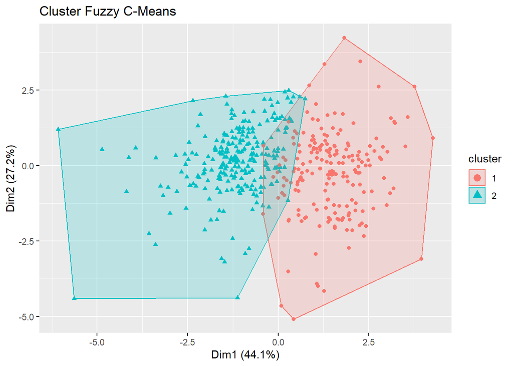

```r
# Visualisasi
fviz_cluster(list(data = fuzzy_log, cluster = cluster_fcm),
             geom = "point",
             ellipse.type = "convex",
             main = "Cluster Fuzzy C-Means")
```

```r
aggregate(data_fuzzy,
          by = list(Cluster = cluster_fcm),
          mean)
```

| Cluster | Fresh | Milk | Grocery | Frozen | Detergents_Paper | Delicassen |
| --- | --- | --- | --- | --- | --- | --- |
| 1 | 9181.845 | 9975.309 | 14314.933 | 2198.505 | 5987.9227 | 2099.876 |
| 2 | 14222.980 | 2500.598 | 2932.785 | 3760.732 | 431.7073 | 1071.411 |

```r
summary(model_fcm$membership)
```

```
##        1                 2
##  Min.   :0.03366   Min.   :0.03396
##  1st Qu.:0.20506   1st Qu.:0.25635
##  Median :0.42792   Median :0.57208
##  Mean   :0.47009   Mean   :0.52991
##  3rd Qu.:0.74365   3rd Qu.:0.79494
##  Max.   :0.96604   Max.   :0.96634
```

```r
model_fcm$membership[1,]
```

```
##         1         2
## 0.7883091 0.2116909
```

### Kesimpulan Model 4

Secara keseluruhan, model Fuzzy C-Means berhasil membentuk dua cluster utama dengan karakteristik berbeda, yaitu kelompok produk segar dan kelompok kebutuhan grosir/ritel. Pemilihan jumlah cluster sebanyak dua didukung oleh metode evaluasi seperti elbow, silhouette, dan FPC.

Nilai FPC (~0.65) menunjukkan kualitas cluster yang cukup baik, sementara nilai silhouette (~0.29) mengindikasikan masih adanya overlap antar cluster. Hal ini sesuai dengan konsep fuzzy clustering, di mana data dapat memiliki keanggotaan pada lebih dari satu cluster, sehingga model ini dinilai tepat untuk merepresentasikan struktur data yang tidak terpisah secara tegas.

# Model Terbaik

## Perbandingan Setiap Model

```r
# Package
library(knitr)
```

```r
# Perbandingan Model
# Model 1 (Euclidean)
euclid_mean <- mean(euclid)
euclid_min  <- min(euclid)
euclid_max  <- max(euclid)

# Model 2 (K-Means)
kmeans_k <- length(unique(k_means$cluster))
kmeans_sil <- mean(sill_score[, 3])
kmeans_balance <- prop.table(table(k_means$cluster))
kmeans_balance_sd <- sd(kmeans_balance)

# Modela 3 (GMM)
gmm_k <- model_gmm$G
gmm_bic <- model_gmm$bic
gmm_loglik <- model_gmm$loglik
gmm_balance <- prop.table(table(model_gmm$classification))
gmm_balance_sd <- sd(gmm_balance)

# Model 4 (Cmeans)
fcm_k <- length(unique(cluster_fcm))
fcm_sil <- mean(sil_skor[, 3])
fcm_fpc <- sum(model_fcm$membership^2) / nrow(fuzzy_log)
fcm_balance <- prop.table(table(cluster_fcm))
fcm_balance_sd <- sd(fcm_balance)

# Gabungkan
perbandingan_model <- data.frame(
  Model = c("Euclidean Distance", "K-Means", "GMM", "Fuzzy C-Means"),
  Jumlah_Cluster = c(NA, kmeans_k, gmm_k, fcm_k),
  Silhouette = c(NA, kmeans_sil, NA, fcm_sil),
  FPC = c(NA, NA, NA, fcm_fpc),
  LogLikelihood = c(NA, NA, gmm_loglik, NA),
  Rata_Rata_Jarak = c(euclid_mean, NA, NA, NA),
  Min_Jarak = c(euclid_min, NA, NA, NA),
  Max_Jarak = c(euclid_max, NA, NA, NA),
  Keseimbangan_Cluster_SD = c(NA, kmeans_balance_sd, gmm_balance_sd, fcm_balance_sd)
)

print(perbandingan_model)
```

```
##                Model Jumlah_Cluster Silhouette       FPC LogLikelihood
## 1 Euclidean Distance             NA         NA        NA            NA
## 2            K-Means              2  0.5914656        NA            NA
## 3                GMM              7         NA        NA     -1262.255
## 4      Fuzzy C-Means              2  0.2961488 0.6523858            NA
##   Rata_Rata_Jarak  Min_Jarak Max_Jarak Keseimbangan_Cluster_SD
## 1        2.581904 0.04433139  21.24427                      NA
## 2              NA         NA        NA              0.57532779
## 3              NA         NA        NA              0.05184988
## 4              NA         NA        NA              0.08356717
```

```r
# Distribusi Cluster
list(
  KMeans = kmeans_balance,
  GMM = gmm_balance,
  FCM = fcm_balance
)
```

```
## $KMeans
##
##          1          2
## 0.09318182 0.90681818
##
## $GMM
##
##          1          2          3          4          5          6          7
## 0.15681818 0.11590909 0.16136364 0.20000000 0.17727273 0.04090909 0.14772727
##
## $FCM
## cluster_fcm
##         1         2
## 0.4409091 0.5590909
```

```r
kable(perbandingan_model, digits = 3,
      caption = "Perbandingan Model Clustering")
```

Perbandingan Model Clustering

| Model | Jumlah_Cluster | Silhouette | FPC | LogLikelihood | Rata_Rata_Jarak | Min_Jarak | Max_Jarak | Keseimbangan_Cluster_SD |
| --- | --- | --- | --- | --- | --- | --- | --- | --- |
| Euclidean Distance | NA | NA | NA | NA | 2.582 | 0.044 | 21.244 | NA |
| K-Means | 2 | 0.591 | NA | NA | NA | NA | NA | 0.575 |
| GMM | 7 | NA | NA | -1262.255 | NA | NA | NA | 0.052 |
| Fuzzy C-Means | 2 | 0.296 | 0.652 | NA | NA | NA | NA | 0.084 |

Berdasarkan tabel perbandingan, terlihat bahwa setiap model memiliki karakteristik performa yang berbeda dalam mengelompokkan data. Metode Euclidean Distance menunjukkan bahwa data memiliki variasi yang cukup tinggi dengan rata-rata jarak sebesar 2.582 serta rentang yang lebar (0.044–21.244), namun metode ini hanya bersifat eksploratif dan belum menghasilkan cluster.

Model GMM menghasilkan 7 cluster dengan nilai log-likelihood sebesar -1262.255 serta nilai keseimbangan cluster paling rendah (SD = 0.052), yang menunjukkan distribusi cluster paling merata. Hal ini mengindikasikan bahwa GMM mampu menangkap struktur data yang lebih kompleks dan menghasilkan segmentasi yang lebih representatif.

Sementara itu, Fuzzy C-Means menghasilkan 2 cluster dengan nilai FPC sebesar 0.652 yang menunjukkan kualitas keanggotaan cukup baik, serta distribusi cluster yang relatif seimbang (SD = 0.084). Namun, nilai silhouette yang rendah (0.296) menunjukkan bahwa pemisahan antar cluster masih kurang tegas.

## Kesimpulan

Berdasarkan hasil perbandingan seluruh model, Gaussian Mixture Model (GMM) dipilih sebagai model terbaik karena mampu merepresentasikan struktur data secara paling optimal. Hal ini ditunjukkan oleh kemampuannya membentuk cluster yang lebih banyak (7 cluster) dan lebih seimbang (SD = 0.052), sehingga mampu menangkap heterogenitas data yang tinggi. Berbeda dengan K-Means yang meskipun memiliki nilai silhouette tinggi namun menghasilkan cluster yang sangat tidak seimbang, serta Fuzzy C-Means yang lebih fleksibel namun memiliki pemisahan cluster yang lemah, GMM menawarkan keseimbangan antara fleksibilitas dan ketepatan segmentasi. Dengan demikian, GMM dinilai paling mampu menggambarkan pola kompleks pelanggan secara lebih detail, representatif, dan realistis.